# NAVER 웹툰 인기순위 분석하기

### 1. 프로젝트 목표 및 내용

많은 사람들이 즐겨보는 네이버 웹툰에서 '인기순, 조회순, 업데이트순, 별점순'이라는 카테고리로 웹툰 링크가 제공된다. 각각의 카테고리에서 높은 순위를 차지할수록 위쪽에 위치하기 때문에 신규유저 및 새로운 웹툰을 탐색하는 사람들에게 영향력있는 자료이다.  
본 프로젝트는 웹툰을 보는 사람들이라면 한번쯤 궁금해했을 '인기있는 웹툰들의 특징'을 분석하여 궁금증을 해소하는 것이 최종 목표이다.  
구체적인 목차는 다음과 같다.  
(1) '조회순'과 '별점순'의 연관성  
(2) '조회순'기준 상위권 웹툰들의 장르  
(3) 인기가 많은 웹툰들의 요일별 분포도

### 2. 주제 선정 이유, 이 프로젝트의 필요성

- 주제 변경 이유

  기존의 주제였던 '날씨에 따른 옷 추천 프로그램'은 데이터를 수집해서 날씨에 맞는 옷을 분류해야했는데, 분류하는 과정에 있어서 어려움이 많았다. 기온을 기준으로 할 때, 한 계절 내에서는 기온은 물론이고 습도나 풍속도 큰 차이가 없어 분류 기준이 애매했으며, 개인적인 주관을 넣게 되면 출력결과가 적절하지 못했다. 또한 객관적인 자료들로만 상하의를 매치할 경우 '옷을 추천한다'라는 목적이 있는 프로그램이 갖추어야할 센스나 개인적인 감을 반영하지 못한다는 것을 깨달았다.  
  무엇보다 많은 양의 데이터를 수집한 만큼, '데이터 분석'에 초점을 맞추어 자료들간의 상관관계를 알아내는 프로젝트를 진행해보고싶다는 생각이 주제를 변경한 가장 큰 이유이다. 또한 이 주제라면 전에 계획했던 프로젝트보다는 많은 사람들이 가질 수 있는 궁금증을 해결할 의미있는 결과를 낼 수 있다고 판단했다.
- 주제 선정 이유

  주제에 대한 아이디어는 두 가지 궁금증에서 시작했다. 평소 주변 친구들과 "~~요일에 볼 웹툰이 없다"라는 말을 할 때마다 특정 요일에 대한 의견이 일치했다. 이 현상에 대한 이유가 나의 주변 사람들과 비슷한 취향을 공유하고 있기 때문인지, 아니면 실제로 전체 웹툰 순위 중 상위권에 있는 웹툰들의 분포가 특히 적은 요일이 있기때문인지 궁금했다.  
  두 번째 궁금증은 신인 웹툰 작가들이 웹툰을 연재할 요일을 정할 때, '인기있는 웹툰이 많은 요일'을 피하는 것이 유리하다고 가정했다. 현시점을 기준으로 했을 때, '어떤 요일을 고르는 것이 조금이라도 더 유리할까?'라는 궁금증이었고, 첫 번째 궁금증과 함께 목차 (3)의 소주제를 정하게 되었다.  
  평소의 궁금증에서 나아가 데이터 분석의 소재를 '웹툰'으로 정할 수 있었고, 웹툰 페이지에서 데이터 크롤링을 이용해 얻을 수 있는 정보들을 이용하여 파악할 수 있는 관계로 (1),(2)번의 분석주제를 정하게 되었다.
- 연구 가설

  (1) 조회순과 별점순이 완전히 비례하지는 않을 것이다. 특정 요일에서 1위를 차지하고 있는 웹툰들의 댓글을 보면, 웹툰의 내용에 대해 문제를 제기하고 논란이 되는 경우가 많고, 오히려 많이 알려지지는 않았지만 보는 사람들만큼은 '명작이다'라는 평가를 하는 웹툰들이 있다. 만약 조회순이 높을 수록 별점순 또한 높다면 그래프로 시각화한 결과에서 주황색 그래프(조회순과 별점순이 비례한다고 가정했을 때의 그래프) 주변에 파란색 그래프가 위치할 것이다. 가설처럼, 전혀 비례하지 않다면 흩어져있는 모습이 눈에 띠게 나타날 것이다. 스캐터(scatter) 그래프를 사용했기 때문에 산포도의 크기를 한눈에 확인할 수 있다.

  (2) 호불호가 확실하게 갈리는 장르들은 비교적 높은 순위에 위치하지 못할 것이다. 예를 들어 '스릴러'와 같은 장르는 '일상'이라는 장르와는 달리 호불호가 확실하게 갈리기 때문에 '스릴러'라는 장르로 등록된 전체 웹툰 수 중 요일별 top10 웹툰에 들어가는 비율이 적을 것이라고 생각한다.

  (3) 이 결과를 통해 실제로 전체 웹툰 순위중 상위권에 위치한 웹툰의 비율이 적은 요일이 있는지, 아니면 나와 내 친구들의 비슷한 취향으로 인해 평소에 그렇게 느꼈던 것인지 알아낼 수 있을 것이다. 표본이 크지 않은 상황에서 요일별로 비슷한 비율을 갖는 것이 오히려 어려울 것이라는 점을 근거로 후자의 생각이 맞을 것이라 생각한다.

### 3. 데이터 획득

```python
import requests
from bs4 import BeautifulSoup
```

모든 데이터 크롤링에서, BeautifulSoup과 requests 모듈을 활용했다.

- 조회순 및 별점순 리스트(순위)
  - 조회순 리스트 webtoon_url = 'https://comic.naver.com/webtoon/weekday.nhn?order=ViewCount'  
    `mon => mon_view`
  - 별점순 리스트 webtoon_url = 'https://comic.naver.com/webtoon/weekday.nhn?order=StarScore'  
    `mon => mon_star`

(1),(2)번 모두 아래의 코드를 사용하여 각각의 링크(네이버 웹툰 페이지)에서 데이터를 획득했고, 각각 요일별로 '_view, _star' 로 나누어 획득한 데이터를 리스트로 만들었다.

#### 1) 조회순 리스트

```python
webtoon_url='https://comic.naver.com/webtoon/weekday.nhn?order=ViewCount'

take = requests.get(webtoon_url)

html=take.text

soup = BeautifulSoup(html, "html.parser")

all_divs = soup.find_all('a',{'class':'title'})

webtoon_list = []
for tag in all_divs:
    result = tag.text.strip()
    webtoon_list.append(result)

mon_view = webtoon_list[:51]
tue_view = webtoon_list[51:103]
wed_view = webtoon_list[103:155]
thu_view = webtoon_list[155:204]
fri_view = webtoon_list[204:252]
sat_view = webtoon_list[252:300]
sun_view = webtoon_list[300:]

week_view = []
week_view.append(mon_view)
week_view.append(tue_view)
week_view.append(wed_view)
week_view.append(thu_view)
week_view.append(fri_view)
week_view.append(sat_view)
week_view.append(sun_view)
```

#### 2) 별점순 리스트

```python
webtoon_url='https://comic.naver.com/webtoon/weekday.nhn?order=StarScore'

take = requests.get(webtoon_url)

html=take.text

soup = BeautifulSoup(html, "html.parser")

all_divs = soup.find_all('a',{'class':'title'})

webtoon_list = []
for tag in all_divs:
    result = tag.text.strip()
    webtoon_list.append(result)

mon_star = webtoon_list[:51]
tue_star = webtoon_list[51:103]
wed_star = webtoon_list[103:155]
thu_star = webtoon_list[155:204]
fri_star = webtoon_list[204:252]
sat_star = webtoon_list[252:300]
sun_star = webtoon_list[300:]
```

#### 3) 웹툰 링크 리스트

> 웹툰의 장르를 알아내기위해서는 웹툰 제목을 클릭해서 상세페이지에 들어가야하므로 모든 링크를 요일별로 정리하였다.  
> 링크를 구하는 코드는 '1. 조회순 리스트'의 4번째줄 코드까지 동일하게 사용했다. (목차 (2)번을 위해 조회순 링크를 사용했다)

```python
webtoon_url='https://comic.naver.com/webtoon/weekday.nhn?order=ViewCount'

take = requests.get(webtoon_url)

html=take.text

soup = BeautifulSoup(html, "html.parser")

#

title_list = soup.select('a.title')
href_list = []

for a in title_list:
    a_href = a.get('href')
    result = f'https://comic.naver.com{a_href}'
    href_list.append(result)

mon_url = href_list[:51]
tue_url = href_list[51:103]
wed_url = href_list[103:155]
thu_url = href_list[155:204]
fri_url = href_list[204:252]
sat_url = href_list[252:300]
sun_url = href_list[300:]

week_url = []
week_url.append(mon_url)
week_url.append(tue_url)
week_url.append(wed_url)
week_url.append(thu_url)
week_url.append(fri_url)
week_url.append(sat_url)
week_url.append(sun_url)
```

#### 4) 장르 데이터 획득하는 함수 구현

> 데이터를 획득하는 아래의 두 가지 함수를 만들었으며, 위에서도 언급했듯이 장르 데이터를 획득한 곳은 웹툰별 상세페이지이다.

```python
# 장르를 찾는 함수

def findgenre(href):
    w_url = href
    g_take = requests.get(w_url)
    g_html = g_take.text
    g_soup = BeautifulSoup(g_html, "html.parser")
    all_genre = g_soup.find_all('span',{'class':'genre'})
    webtoon_genre = []
    for i in all_genre:
        g_result = i.text.strip()
        webtoon_genre.append(g_result)
        return webtoon_genre

# (요일별) 리스트에 추가하는 함수

def addtolist(list,item):
    list.append(item)
    return list
```

#### >> 장르 데이터 획득

```python
mon_glist = []
tue_glist = []
wed_glist = []
thu_glist = []
fri_glist = []
sat_glist = []
sun_glist = []

for j in mon_url:
    z = findgenre(j)
    mon_list = addtolist(mon_glist, z)
for j in tue_url:
    z = findgenre(j)
    tue_list = addtolist(tue_glist, z)
for j in wed_url:
    z = findgenre(j)
    wed_list = addtolist(wed_glist, z)
for j in thu_url:
    z = findgenre(j)
    thu_list = addtolist(thu_glist, z)
for j in fri_url:
    z = findgenre(j)
    fri_list = addtolist(fri_glist, z)
for j in sat_url:
    z = findgenre(j)
    sat_list = addtolist(sat_glist, z)
for j in sun_url:
    z = findgenre(j)
    sun_list = addtolist(sun_glist, z)

# 'mon'(monday)에서부터 'sun'(sunday)까지 같은 방식으로 장르관련 데이터를 획득하였다.
```

### 4. 구현 내용 설명

#### (1) 조회순과 별점순의 연관성

- find_order 함수 / find_gap 함수

  > find_gap 함수는 '조회순'을 기준으로, 조회순 순위에서 요일_star 리스트에서의 순위를 빼 요일_gap 리스트를 구했다.  
  > 월요일에서 일요일까지 해석적인 측면에서 큰 차이가 없어 월요일과 금요일 자료만을 사용했다.

```python
def find_order(item, lst,n=0):
    if not lst:
        return None
    elif lst[0] == item:
        return n
    else:
        return find_order(item, lst[1:],n+1)

def find_gap(day_view):
    day_gap = []
    for i in range(len(day_view)):
        star = find_order(day_view[i],mon_star)
        day_gap.append(i-star)
        print(day_gap)
```

> 각 요소의 조회순과 별점순의 차이를 구해 리스트에 담는다.

```python
mon_gap = []
fri_gap = []

for i in range(len(mon_view)):
    star = find_order(mon_view[i],mon_star)
    mon_gap.append(i-star)
for i in range(len(fri_view)):
    star = find_order(fri_view[i],fri_star)
    fri_gap.append(i-star)

# 프린트 결과는 10.별첨에 첨부
#print(mon_gap)
#print(fri_gap)
```

> 차이값을 이용해서 조회순위(n위)와 별점순위(n위)를 구한다.

```python
a_mon = list(range(len(mon_view)))
a_fri = list(range(len(fri_view)))

b_mon = []
b_fri = []

for i in range(len(mon_gap)):
    b_mon.append(a_mon[i]-mon_gap[i])
for i in range(len(fri_gap)):
    b_fri.append(a_fri[i]-fri_gap[i])

# 프린트 결과는 10.별첨에 첨부
#print(a_mon)
#print(b_mon)
#print(a_fri)
#print(b_fri)
```

#### (2) 조회순 기준 상위권 웹툰들의 장르

- 획득 데이터 가공

> 장르 데이터가 ['에피소드, 액션'] 과 같은 형태로 list안에 들어있었기 때문에 (1) ['에피소드', '액션']의 형태로 바꾸고,  
> 장르의 개수를 세기 위해서 (2) 하나의 리스트에 넣었다.

```python
# (1)
# mon'(monday)에서부터 'sun'(sunday)까지 같은 방식으로 new_(mon~sun)list를 구했다.

new_monlist = []
new_tuelist = []
new_wedlist = []
new_thulist = []
new_frilist = []
new_satlist = []
new_sunlist = []

for s in range(len(mon_list)):
    new_monlist.extend(mon_list[s][0].split(", "))
for s in range(len(tue_list)):
    new_tuelist.extend(tue_list[s][0].split(", "))
for s in range(len(wed_list)):
    new_wedlist.extend(wed_list[s][0].split(", "))
for s in range(len(thu_list)):
    new_thulist.extend(thu_list[s][0].split(", "))
for s in range(len(fri_list)):
    new_frilist.extend(fri_list[s][0].split(", "))
for s in range(len(sat_list)):
    new_satlist.extend(sat_list[s][0].split(", "))
for s in range(len(sun_list)):
    new_sunlist.extend(sun_list[s][0].split(", "))
```

```python
# (2)
# 10. 별첨 * 하나의 리스트에 넣기
```

> 각각의 장르에 해당하는 웹툰이 몇개인지 구한다.

```python
genre1 = ['에피소드', '옴니버스', '스토리']
genre2 = ['일상', '개그', '판타지', '액션', '드라마', '감성', '스릴러', '시대극', '스포츠']

g1_list = []

for i in genre1:
    g1 = flat.count(i)
    g1_list.append(g1)
    print(i, g1)

print('-----------')

g2_list = []

for j in genre2:
    g2 = flat.count(j)
    g2_list.append(g2)
    print(j, g2)

# 프린트 결과는 10.별첨에 첨부
#print(g1_list)
#print(g2_list)
```

```
에피소드 44
옴니버스 14
스토리 296
-----------
일상 13
개그 20
판타지 62
액션 39
드라마 93
감성 3
스릴러 50
시대극 5
스포츠 6
```

> 요일별 상위 10위까지에 해당하는 웹툰들의 장르 리스트를 하나의 리스트(top10)에 담는다.

```python
top10_0 = new_monlist[:10*2]
top10_1 = new_tuelist[:10*2]
top10_2 = new_wedlist[:10*2]
top10_3 = new_thulist[:10*2]
top10_4 = new_frilist[:10*2]
top10_5 = new_satlist[:10*2]
top10_6 = new_sunlist[:10*2]

top10 = []
top10.extend(top10_0)
top10.extend(top10_1)
top10.extend(top10_2)
top10.extend(top10_3)
top10.extend(top10_4)
top10.extend(top10_5)
top10.extend(top10_6)
```

```python
genre1 = ['에피소드', '옴니버스', '스토리']
genre2 = ['일상', '개그', '판타지', '액션', '드라마', '감성', '스릴러', '시대극', '스포츠']

g1_top = []

for i in genre1:
    g1 = top10.count(i)
    g1_top.append(g1)
    print(i, g1)

print('-----------')

g2_top = []

for j in genre2:
    g2 = top10.count(j)
    g2_top.append(g2)
    print(j, g2)

#print(g1_top)
#print(g2_top)
```

```
에피소드 8
옴니버스 2
스토리 60
-----------
일상 1
개그 1
판타지 14
액션 17
드라마 22
감성 0
스릴러 5
시대극 1
스포츠 2
```

#### (3) 인기가 많은 웹툰들의 요일별 분포도

```python
top30 = ['여신강림', '유미의 세포들', '외모지상주의', '인생존망', '연애혁명', '싸움독학', '프리드로우','좀비딸','소녀의 세계','고수','회춘','기기괴괴','재혼 황후','간 떨어지는 동거','이제 곧 죽습니다','바른연애 길잡이','신의 탑','호랑이형님','뷰티풀 군바리','더 복서','스위트홈','맘마미안','전지적 독자 시점','취사병 전설이 되다','갓 오브 하이스쿨','마음의소리','하루만 네가 되고 싶어','백수세끼','이두나!','그래서 나는 안티팬과 결혼했다']
```

#### >> `overlap 함수` 구현

```python
def overlap(a,b):
    count = 0
    for o in b:
        if o in a:
            count += 1
    return count
```

```python
for i in week_view:
    over = overlap(i,top30)
    print(over)
```

```
5
4
3
6
5
5
2
```

### 5. 분석 결과 또는 구현 결과

#### (1) 조회순과 별점순의 연관성

```python
import matplotlib.pyplot as plt
```

#### `Monday`

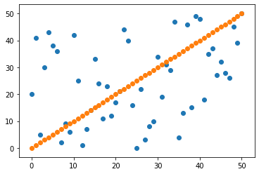

```python
plt.figure()
plt.scatter(a_mon,b_mon)
plt.scatter(a_mon,a_mon)
plt.show()
```

#### `Friday`

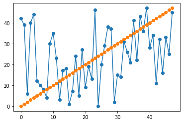

```python
plt.figure()
plt.plot(a_fri,b_fri,marker='o')
plt.plot(a_fri,a_fri,marker='o')
plt.show()
```

#### (2) 조회순 기준 상위권 웹툰들의 장르

#### `ratio`

```python
ratio1 = []
ratio2 = []

for i in range(len(g1_top)):
    percent1 = (g1_top[i]/g1_list[i])*100
    ratio1.append(percent1)

for j in range(len(g2_top)):
    if g2_list[j] != 0:
        percent2 = (g2_top[j]/g2_list[j])*100
        ratio2.append(percent2)
    else :
        percent2 = 'no value'
        ratio2.append(percent2)

print(ratio1)
print(ratio2)
```

```
[18.181818181818183, 14.285714285714285, 20.27027027027027]
[7.6923076923076925, 5.0, 22.58064516129032, 43.58974358974359, 23.655913978494624, 0.0, 10.0, 20.0, 33.33333333333333]
```

```python
from matplotlib import pyplot as plt
import numpy as np
```

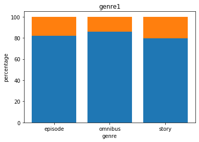

```python
topics = ['episode', 'omnibus', 'story']

_ratio1 = []
for i in range(len(ratio1)):
    _ratio1.append(100-ratio1[i])

c_bottom = np.add(_ratio1, ratio1)

x = range(len(topics))

plt.bar(x, _ratio1)
plt.bar(x, ratio1, bottom=_ratio1)

ax = plt.subplot()
ax.set_xticks(x)
ax.set_xticklabels(topics)

plt.title('genre1')
plt.xlabel('genre')
plt.ylabel('percentage')

plt.show()
```

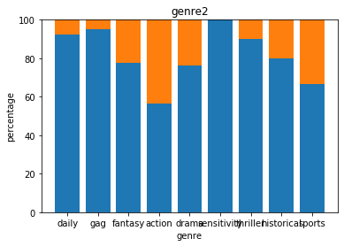

```python
topics = ['daily', 'gag', 'fantasy', 'action', 'drama', 'sensitivity', 'thriller', 'historical', 'sports']

_ratio2 = []
for i in range(len(ratio2)):
    _ratio2.append(100-ratio2[i])

c_bottom = np.add(_ratio2, ratio2)

x = range(len(topics))

plt.bar(x, _ratio2)
plt.bar(x, ratio2, bottom=_ratio2)

ax = plt.subplot()
ax.set_xticks(x)
ax.set_xticklabels(topics)

plt.title('genre2')
plt.xlabel('genre')
plt.ylabel('percentage')

plt.show()
```

#### (3) 인기가 많은 웹툰들의 요일별 분포도

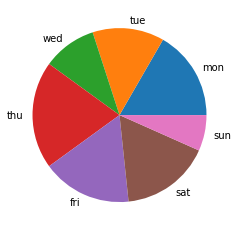

```python
plt.figure()

label = ['mon', 'tue', 'wed', 'thu', 'fri', 'sat', 'sun']
data_ratio = [5, 4, 3, 6, 5, 5, 2]# 데이터 비율

plt.pie(data_ratio, labels = label)

plt.show()
```

### 6. 결론

#### (1) 조회순과 별점순의 연관성

> 첫 번째 분석의 가설은 다음과 같았다.  
> "조회순과 별점순이 완전히 비례하지는 않을 것이다."

> 어쩌면 사람들이 오로지 그 작품의 완성도나 유익한 정도를 우선적으로 따지기보다는 자극적일수록, 그리고 흥미로울수록 더 그 작품에 끌리기 때문이라고 추측해볼 수 있다.

#### (2) 조회순 기준 상위권 웹툰들의 장르

> 두 번째 분석의 가설은 다음과 같았다.  
> "`스릴러`처럼, 호불호가 확실하게 갈리는 장르들은 비교적 높은 순위에 위치하지 못할 것이다."

#### (3) 인기가 많은 웹툰들의 요일별 분포도

> 세 번째 분석의 가설은 다음과 같았다.  
> "실제로 전체 웹툰 순위중 상위권에 위치한 웹툰의 비율이 적은 요일이 있을 것이다."

> 요일을 통합한 전체 웹툰 순위에서 top30에 위치한 웹툰들이 일요일(다음으로는 수요일)에 특히 적게 분포되어있다는 것을 확인할 수 있었다. 가설에 대해서는 맞다고 할 수 있지만, 이 소재를 떠올리게 된 궁금증 두 가지에서 생각해보면 다른 해석을 할 수 있다.

> > `궁금증 1`. 특정 요일에 볼만한 웹툰이 별로 없는 이유가 이 의견을 공유한 나와 주변 사람들의 취향이 비슷해서일까?, 아니면 실제로 상위권 웹툰이 특정 요일에 적게 있기 때문일까?  
> > `A` : 후자가 사실이긴하나, 내가 생각했던 요일과는 달랐기 때문에 단순히 개인적인 취향 때문에 그렇게 느낀 것이라고 볼 수 있다. 그리고 이 말은 그렇게 느끼지 않는 사람들도 많다는 것을 뜻한다.  
> > `궁금증 2`. 신인 웹툰 작가가 웹툰을 연재할 요일을 정하려고 할 때, 어떤 요일을 추천해주는 것이 신인 작가가 유리한 선택을 할 수 있도록 도와주는 것일까?  
> > `A` : 자료만 봤을 때는 일요일을 추천하고 싶으나, 그 요일이 절대적으로 유리하다고 보장할 수는 없다. 그 이유는 첫째, top30의 순위가 빈번하게 바뀌고, 둘째, 궁금증 1의 답변에서 말했듯이 수치적인 통계자료와는 다르게, 사람들의 취향에 따라 일요일의 순위가 낮은 웹툰들을 여러개 즐겨보는 사람들이 많을 수 있다.

#### >> 통합 결론

> 본 프로젝트의 최종 목표였던 "한 번쯤 궁금해했을 '인기 있는 웹툰들의 특징'을 분석하여 궁금증을 해소하는 것"은 이루었다고 생각한다.  
> 객관적인 수치들로 만들어진 데이터들을 바탕으로 분석을 해본 것은 평소 궁금했던 궁금증들을 해소하는 데에 도움을 주었으나, 마치 '일일 운세'나 '재미로 보는' 시리즈처럼 가볍게 읽고 넘어가야 할 분석 결과라는 점을 깨달았다. 가장 중요한 것은 개인의 취향이며, 그 취향은 너무나 다양하다. 따라서 서로의 취향을 존중해주는 문화가 현재 우리에게 가장 필요하다.

### 7. 오픈소스 활용한 부분

- `3. 데이터 획득`의 데이터 크롤링 부분

> 1) 조회순 리스트, 2) 별점순 리스트  
> 여러 글의 코드들을 조합하여 작성  
> https://blog.naver.com/bosongmoon/221581943490  
> https://www.youtube.com/watch?v=8rgCwpA4Fms

> 3) 웹툰 링크 리스트, 4) 장르 데이터 획득하는 함수 구현  
> https://blog.naver.com/rich_flavor/221696895033
- `4. 구현 내용 설명` 중 find_order 함수를 제외한 나머지(획득 데이터 가공한 부분)는 모두 직접 만듬.
> 1. find_order 함수 : https://stackoverflow.com/questions/14424351/finding-the-order-number-of-an-element-in-a-list
> 2. find_gap 함수 : 직접 만듬
- `5. 분석 결과 또는 구현 결과`에서 'ratio' 부분만 직접 구현하고, 그래프 구현을 위한 코드들은 `8. 참고문헌`에 첨부된 링크에서 가져와 수정함

### 8. 참고문헌

1. python을 이용한 시각화를 위해 참조한 글

   > https://zzsza.github.io/development/2018/08/24/data-visualization-in-python/  
   > https://dailyheumsi.tistory.com/36  
   > http://hleecaster.com/python-matplotlib-bar-graph/
2. 참조한 책

   > `파이썬으로 배우는 웹 크롤러 | 박정태 저 | 정보문화사`

### 9. 별첨: 3에서 획득한 데이터 원본

```python
import requests
from bs4 import BeautifulSoup
```

#### 1) 조회순 리스트

```python
print(mon_view)
print(tue_view)
print(wed_view)
print(thu_view)
print(fri_view)
print(sat_view)
print(sun_view)
```

```
['신의 탑', '뷰티풀 군바리', '소녀의 세계', '윈드브레이커', '인생존망', '평범한 8반', '백수세끼', '귀전구담', '장씨세가 호위무사', '칼가는 소녀', '데드라이프', '니편내편', '유일무이 로맨스', '앵무살수', '야자괴담', '링크보이', '요리GO', '히어로메이커', '서브 콤플렉스', '이것도 친구라고', '사장님을 잠금해제', '첫사랑입니다만', '일진이 사나워', '두근두근 네가 좋아서', '교환일기', '오늘의 순정망화', '삶이 우리를 속일지라도', '아는 여자애', '꿈의 기업', '와이키…
['여신강림', '마음의소리', '랜덤채팅의 그녀!', '사이드킥 2~3', '바른연애 길잡이', '체크포인트', '신도림', '사신소년', '한림체육관', '원주민 공포만화', '하루만 네가 되고 싶어', '신의 언어', '빙탕후루', '중증외상센터 : 골든 아워', '은주의 방 2~3부', '윌유메리미', '에이머', '삼국지톡', '제로게임', '용왕님의 셰프가 되었습니다', '견우와 선녀', '악마와 계약연애', '열정호구', '하우스키퍼', '집이 없어', '자판귀', '오늘의 순정망화', '문래빗', '어글리 피플즈', …
['고수', '복학왕', '전지적 독자 시점', '연놈', '헬퍼 2 : 킬베로스', '튜토리얼 탑의 고인물', '격기3반', '레사 시즌2~3', '그래서 나는 안티팬과 결혼했다', '고삼무쌍', '일렉시드', '여주실격!', '이츠마인', '모죠의 일지', '원수를 사랑하라', '세상은 돈과 권력', '언덕 위의 제임스', '판타지 여동생!', '범이올시다!', '귀곡의 문', '그 판타지 세계에서 사는 법', '더 트웰브', '갓물주', '방탈출', '캐슬', '얼굴천재', '정순애 식당', '203호 저승사자', '칼부림',…
['연애혁명', '기기괴괴', '좀비딸', '더 복서', '이두나!', '최강전설 강해효', '전자오락수호대', '간 떨어지는 동거', '하드캐리', '화이트 블러드', '쿠베라', '데이빗', '가담항설', '겟백', '꽃만 키우는데 너무강함', '병의 기록', '만물의 영장', '가타부타타', '신비', '집사레인저', '온새미로', '당신의 과녁', '특수 영능력 수사반', '오늘의 순정망화', '무사만리행', '킬더킹', '어쩔꼰대', '무모협지', '날 가져요', '셧업앤댄스', '로그아웃', '롤랑롤랑', '소녀180',…
['외모지상주의', '갓 오브 하이스쿨', '스위트홈', '이제 곧 죽습니다', '더 게이머', '재혼 황후', '개를 낳았다', '닥터 프로스트 시즌 3~4', '1초', '낙향문사전', '플레이어', '화장 지워주는 남자', '걸어서 30분', '삼국지톡', '난약', '냐한남자', '트럼프', '몽홀', '현혹', '옆집친구', '소심한 팔레트', '복학생 정순이', '금혼령-조선혼인금지령', '얌전한 사이', '골든 체인지', '하르모니아', '가슴털 로망스', '신상 미스터리 극장', '헬로도사', '고래별', '도롱이',…
['유미의 세포들', '호랑이형님', '프리드로우', '회춘', '취사병 전설이 되다', '비질란테', '스터디그룹', '나이트런', '윌유메리미', '어글리후드', '모죠의 일지', '초인의 시대', '아테나 컴플렉스', '민간인 통제구역', '나를 바꿔줘', '갓핑크', '먹이', '언데드', '두번째 생일', '친애하는 X', '탑코너', '동트는 로맨스', '홍시는 날 좋아해!', '열불 로맨스', '공유몽', '토끼대왕', '틴맘', '피라미드 게임', '여고전설', '왕세자 입학도', '우주최강대스타', '꼬리 있는 연애…
['싸움독학', '열렙전사', '약한영웅', '마법스크롤 상인 지오', '다이스(DICE)', '맘마미안', '데이빗', '소녀재판', '돼지우리', '검은인간', '도망자', '운수 오진 날', '내일', '구름이 피워낸 꽃', '극야', '신이 담긴 아이', '잉여특공대', '인어를 위한 수영교실', '오로지 너를 이기고 싶어', '닭강정', '행성인간', '호러전파상', '강남도깨비', '가비지타임', '패밀리 사이즈', '닥터앤닥터 육아일기', '여름은 뜨겁다', '아르세니아의 마법사', '이번 생도 잘 부탁해', '괴물신부…
```

#### 2) 별점순 리스트

```python
print(mon_star)
print(tue_star)
print(wed_star)
print(thu_star)
print(fri_star)
print(sat_star)
print(sun_star)
```

```
['오늘의 순정망화', '유일무이 로맨스', '귀전구담', '아는 여자애', '닥터 하운드', '소녀의 세계', '칼가는 소녀', '앵무살수', '꿈의 기업', '장씨세가 호위무사', '와이키키 뱀파이어', '히어로메이커', '이것도 친구라고', '위대한 방옥숙', '야자괴담', '노력의 결과', '교환일기', '사장님을 잠금해제', '하슬라', '도플갱어의 게임', '신의 탑', '첫사랑입니다만', '삶이 우리를 속일지라도', '서브 콤플렉스', '요리GO', '니편내편', '결백한 사람은 없다', '여기 악마가 있어', '인간의…
['오늘의 순정망화', '악마와 계약연애', '숲속의 담', '정년이', '하루만 네가 되고 싶어', '견우와 선녀', '제로게임', '용왕님의 셰프가 되었습니다', '너에게만 보이는', '그놈은 흑염룡', '문래빗', '바른연애 길잡이', '사이드킥 2~3', '하우스키퍼', '패밀리 사이즈', '그날 죽은 나는', '빙탕후루', '체크포인트', '저세상 클라스!', '중증외상센터 : 골든 아워', '신도림', '삼국지톡', '땅 보고 걷는 아이', '올가미', '자판귀', '필살VS로맨스', '헬58', '사신소년', '피와 살…
['귀곡의 문', '당신의 향수', '정순애 식당', '텃밭부 사건일지', '오라존미', '그 판타지 세계에서 사는 법', '이츠마인', '범이올시다!', '닥터앤닥터 육아일기', '고수', '미래의 골동품 가게', '푸른사막 아아루', '모죠의 일지', '레사 시즌2~3', '여주실격!', 'FM보이', '캐슬', '원수를 사랑하라', '그래서 나는 안티팬과 결혼했다', '나의 우주', '고삼무쌍', '럭키언럭키', '귀신이지만 사랑하고 싶어', '아도나이', '방탈출', '오버더문', '언덕 위의 제임스', '203호 저승사자'…
['오늘의 순정망화', '가담항설', '롤랑롤랑', '겟백', '신비', '만물의 영장', '독립일기', '방 안의 코끼리', '화이트 블러드', '간 떨어지는 동거', '전자오락수호대', '좀비딸', '셧업앤댄스', '이두나!', '셈하는 사이', '밤하늘에 구름운', '쿠베라', '꽃만 키우는데 너무강함', '갓도령스', '당신의 과녁', '무모협지', '안개무덤', '더 복서', '가타부타타', '날 가져요', '손아귀', '기기괴괴', '데이빗', '소녀180', '하드캐리', '로그아웃', '집사레인저', '열등의 조건',…
['골든 체인지', '냐한남자', '고래별', '걸어서 30분', '1초', '현혹', '스위트홈', '트럼프', '닥터 프로스트 시즌 3~4', '소심한 팔레트', '개를 낳았다', '꼬맹이를 부탁해!', '재혼 황후', '금혼령-조선혼인금지령', '스윗솔티', '도롱이', '합법해적 파르페', '삼국지톡', '난약', '복학생 정순이', '하르모니아', '후덜덜덜 남극전자', '너의 미소가 함정', '화장 지워주는 남자', '몽홀', '나의 첫번째 새벽', '구독금지', '옆집친구', '개미', '가슴털 로망스', '낙향문사전'…
['어글리후드', '마음의 숙제', '아홉수 우리들', '먹이', '왕세자 입학도', '비질란테', '호랑이형님', '홍시는 날 좋아해!', '친애하는 X', '동트는 로맨스', '모죠의 일지', '초인의 시대', '취사병 전설이 되다', '갓핑크', '열불 로맨스', '두번째 생일', '천사가 아니야', '스터디그룹', '먹지마세요', '민간인 통제구역', '누군가의 로섬', '토끼대왕', '나이트런', '유령극단', '유미의 세포들', '저무는 해, 시린 눈', '머리카락을 뽑으면', '윌유메리미', '꼬리 있는 연애', '거미…
['합격시켜주세용', '이번 생도 잘 부탁해', '검은인간', '구름이 피워낸 꽃', '인어를 위한 수영교실', '독립일기', '내일', '닥터앤닥터 육아일기', '무주의 맹시', '맘마미안', '만찢남녀', '마법스크롤 상인 지오', '오로지 너를 이기고 싶어', '패밀리 사이즈', '극야', '가비지타임', '꽃 피는 날', '오늘도 사랑하세요', '열렙전사', '괴물신부', '라일락 200%', '평행도시', '행성인간', '그녀의 버킷리스트', '경비 배두만', '별이삼샵', '약한영웅', '데이빗', '도망자', '속삭이는…
```

#### 3) 웹툰 링크 리스트

```python
print(mon_url)
print(tue_url)
print(wed_url)
print(thu_url)
print(fri_url)
print(sat_url)
print(sun_url)
```

[output not shown]

#### 4) 장르 데이터 획득하는 함수 구현

```python
print(mon_list)
print(tue_list)
print(wed_list)
print(thu_list)
print(fri_list)
print(sat_list)
print(sun_list)
```

```
[['스토리, 판타지'], ['스토리, 드라마'], ['스토리, 드라마'], ['스토리, 스포츠'], ['에피소드, 액션'], ['스토리, 드라마'], ['스토리, 드라마'], ['옴니버스, 스릴러'], ['스토리, 시대극'], ['에피소드, 드라마'], ['스토리, 액션'], ['스토리, 드라마'], ['스토리, 로맨스'], ['스토리, 판타지'], ['옴니버스, 스릴러'], ['스토리, 판타지'], ['스토리, 드라마'], ['옴니버스, 판타지'], ['에피소드, 로맨스'], ['스토리, 드라마'], ['스토리, 개그'], ['…
[['스토리, 로맨스'], ['에피소드, 개그'], ['스토리, 드라마'], ['스토리, 판타지'], ['스토리, 로맨스'], ['스토리, 드라마'], ['스토리, 액션'], ['스토리, 액션'], ['에피소드, 액션'], ['스토리, 스릴러'], ['스토리, 판타지'], ['스토리, 판타지'], ['에피소드, 판타지'], ['스토리, 드라마'], ['스토리, 드라마'], ['에피소드, 일상'], ['스토리, 판타지'], ['에피소드, 시대극'], ['스토리, 판타지'], ['스토리, 판타지'], ['스토리, 드라마'], ['스토리…
[['스토리, 액션'], ['스토리, 드라마'], ['스토리, 판타지'], ['스토리, 드라마'], ['스토리, 액션'], ['스토리, 액션'], ['스토리, 스포츠'], ['스토리, 판타지'], ['스토리, 로맨스'], ['스토리, 액션'], ['스토리, 액션'], ['스토리, 드라마'], ['스토리, 스릴러'], ['에피소드, 개그'], ['스토리, 로맨스'], ['에피소드, 드라마'], ['에피소드, 개그'], ['스토리, 판타지'], ['에피소드, 일상'], ['스토리, 드라마'], ['스토리, 판타지'], ['스토리, 스릴…
[['스토리, 드라마'], ['옴니버스, 스릴러'], ['스토리, 드라마'], ['스토리, 액션'], ['스토리, 로맨스'], ['스토리, 액션'], ['스토리, 판타지'], ['스토리, 로맨스'], ['스토리, 드라마'], ['스토리, 판타지'], ['스토리, 판타지'], ['스토리, 드라마'], ['스토리, 판타지'], ['에피소드, 드라마'], ['스토리, 판타지'], ['에피소드, 드라마'], ['에피소드, 개그'], ['스토리, 로맨스'], ['스토리, 로맨스'], ['스토리, 액션'], ['스토리, 로맨스'], ['스토리…
[['스토리, 드라마'], ['스토리, 액션'], ['스토리, 스릴러'], ['스토리, 드라마'], ['스토리, 판타지'], ['스토리, 로맨스'], ['스토리, 드라마'], ['스토리, 드라마'], ['스토리, 드라마'], ['스토리, 판타지'], ['스토리, 액션'], ['에피소드, 드라마'], ['스토리, 로맨스'], ['에피소드, 시대극'], ['스토리, 판타지'], ['스토리, 로맨스'], ['스토리, 판타지'], ['스토리, 시대극'], ['스토리, 스릴러'], ['스토리, 로맨스'], ['스토리, 로맨스'], ['스토리…
[['에피소드, 로맨스'], ['스토리, 액션'], ['스토리, 드라마'], ['에피소드, 드라마'], ['스토리, 판타지'], ['스토리, 액션'], ['스토리, 액션'], ['스토리, 판타지'], ['에피소드, 일상'], ['스토리, 판타지'], ['에피소드, 개그'], ['스토리, 액션'], ['스토리, 판타지'], ['스토리, 스릴러'], ['스토리, 드라마'], ['스토리, 액션'], ['옴니버스, 스릴러'], ['스토리, 스릴러'], ['스토리, 스릴러'], ['스토리, 드라마'], ['스토리, 스포츠'], ['스토리, …
[['스토리, 액션'], ['스토리, 판타지'], ['에피소드, 액션'], ['스토리, 판타지'], ['스토리, 판타지'], ['스토리, 드라마'], ['스토리, 드라마'], ['스토리, 드라마'], ['스토리, 스릴러'], ['스토리, 액션'], ['스토리, 액션'], ['스토리, 스릴러'], ['옴니버스, 드라마'], ['스토리, 로맨스'], ['스토리, 스릴러'], ['스토리, 판타지'], ['스토리, 판타지'], ['스토리, 로맨스'], ['에피소드, 로맨스'], ['스토리, 개그'], ['스토리, 스릴러'], ['옴니버스,…
```

### 10. 별첨: 4에서 가공한 데이터 원본

```python
print(mon_gap)
print(fri_gap)
```

```
[-20, -40, -3, -27, -39, -33, -30, 5, -1, 3, -32, -14, 11, 6, 0, -18, -8, 6, -5, 7, 3, 0, -22, -17, 8, 25, 4, 24, 20, 19, -4, 12, 1, 4, -13, 31, 23, -9, 23, -10, -8, 23, 7, 6, 17, 13, 18, 21, 3, 10, 0]
[-42, -38, -4, -37, -40, -7, -4, -1, 4, -21, -25, -12, 9, -4, -4, 14, 9, -7, 13, -8, 11, 2, 9, -23, 24, 5, -3, -11, -9, 27, 15, 17, 1, 7, 13, -6, 14, -6, 2, -8, 12, 7, 31, 11, 28, 12, 21, 2]
```

```python
print(a_mon)
print(b_mon)
print(a_fri)
print(b_fri)
```

```
[0, 1, 2, 3, 4, 5, 6, 7, 8, 9, 10, 11, 12, 13, 14, 15, 16, 17, 18, 19, 20, 21, 22, 23, 24, 25, 26, 27, 28, 29, 30, 31, 32, 33, 34, 35, 36, 37, 38, 39, 40, 41, 42, 43, 44, 45, 46, 47, 48, 49, 50]
[20, 41, 5, 30, 43, 38, 36, 2, 9, 6, 42, 25, 1, 7, 14, 33, 24, 11, 23, 12, 17, 21, 44, 40, 16, 0, 22, 3, 8, 10, 34, 19, 31, 29, 47, 4, 13, 46, 15, 49, 48, 18, 35, 37, 27, 32, 28, 26, 45, 39, 50]
[0, 1, 2, 3, 4, 5, 6, 7, 8, 9, 10, 11, 12, 13, 14, 15, 16, 17, 18, 19, 20, 21, 22, 23, 24, 25, 26, 27, 28, 29, 30, 31, 32, 33, 34, 35, 36, 37, 38, 39, 40, 41, 42, 43, 44, 45, 46, 47]
[42, 39, 6, 40, 44, 12, 10, 8, 4, 30, 35, 23, 3, 17, 18, 1, 7, 24, 5, 27, 9, 19, 13, 46, 0, 20, 29, 38, 37, 2, 15, 14, 31, 26, 21, 41, 22, 43, 36, 47, 28, 34, 11, 32, 16, 33, 25, 45]
```

#### >> 데이터 가공

```
 ex) ['에피소드, 액션'] => ['에피소드', '액션']
```

```python
print(new_monlist)
print(new_tuelist)
print(new_wedlist)
print(new_thulist)
print(new_frilist)
print(new_satlist)
print(new_sunlist)
```

```
['스토리', '판타지', '스토리', '드라마', '스토리', '드라마', '스토리', '스포츠', '에피소드', '액션', '스토리', '드라마', '스토리', '드라마', '옴니버스', '스릴러', '스토리', '시대극', '에피소드', '드라마', '스토리', '액션', '스토리', '드라마', '스토리', '로맨스', '스토리', '판타지', '옴니버스', '스릴러', '스토리', '판타지', '스토리', '드라마', '옴니버스', '판타지', '에피소드', '로맨스', '스토리', '드라마', '스토리', '개그', '스…
['스토리', '로맨스', '에피소드', '개그', '스토리', '드라마', '스토리', '판타지', '스토리', '로맨스', '스토리', '드라마', '스토리', '액션', '스토리', '액션', '에피소드', '액션', '스토리', '스릴러', '스토리', '판타지', '스토리', '판타지', '에피소드', '판타지', '스토리', '드라마', '스토리', '드라마', '에피소드', '일상', '스토리', '판타지', '에피소드', '시대극', '스토리', '판타지', '스토리', '판타지', '스토리', '드라마', '스토리'…
['스토리', '액션', '스토리', '드라마', '스토리', '판타지', '스토리', '드라마', '스토리', '액션', '스토리', '액션', '스토리', '스포츠', '스토리', '판타지', '스토리', '로맨스', '스토리', '액션', '스토리', '액션', '스토리', '드라마', '스토리', '스릴러', '에피소드', '개그', '스토리', '로맨스', '에피소드', '드라마', '에피소드', '개그', '스토리', '판타지', '에피소드', '일상', '스토리', '드라마', '스토리', '판타지', '스토리', '스…
['스토리', '드라마', '옴니버스', '스릴러', '스토리', '드라마', '스토리', '액션', '스토리', '로맨스', '스토리', '액션', '스토리', '판타지', '스토리', '로맨스', '스토리', '드라마', '스토리', '판타지', '스토리', '판타지', '스토리', '드라마', '스토리', '판타지', '에피소드', '드라마', '스토리', '판타지', '에피소드', '드라마', '에피소드', '개그', '스토리', '로맨스', '스토리', '로맨스', '스토리', '액션', '스토리', '로맨스', '스토리'…
['스토리', '드라마', '스토리', '액션', '스토리', '스릴러', '스토리', '드라마', '스토리', '판타지', '스토리', '로맨스', '스토리', '드라마', '스토리', '드라마', '스토리', '드라마', '스토리', '판타지', '스토리', '액션', '에피소드', '드라마', '스토리', '로맨스', '에피소드', '시대극', '스토리', '판타지', '스토리', '로맨스', '스토리', '판타지', '스토리', '시대극', '스토리', '스릴러', '스토리', '로맨스', '스토리', '로맨스', '스토리'…
['에피소드', '로맨스', '스토리', '액션', '스토리', '드라마', '에피소드', '드라마', '스토리', '판타지', '스토리', '액션', '스토리', '액션', '스토리', '판타지', '에피소드', '일상', '스토리', '판타지', '에피소드', '개그', '스토리', '액션', '스토리', '판타지', '스토리', '스릴러', '스토리', '드라마', '스토리', '액션', '옴니버스', '스릴러', '스토리', '스릴러', '스토리', '스릴러', '스토리', '드라마', '스토리', '스포츠', '스토리', …
['스토리', '액션', '스토리', '판타지', '에피소드', '액션', '스토리', '판타지', '스토리', '판타지', '스토리', '드라마', '스토리', '드라마', '스토리', '드라마', '스토리', '스릴러', '스토리', '액션', '스토리', '액션', '스토리', '스릴러', '옴니버스', '드라마', '스토리', '로맨스', '스토리', '스릴러', '스토리', '판타지', '스토리', '판타지', '스토리', '로맨스', '에피소드', '로맨스', '스토리', '개그', '스토리', '스릴러', '옴니버스',…
```

#### >> 하나의 리스트에 넣기

```python
flat = []
flat.extend(new_monlist)
flat.extend(new_tuelist)
flat.extend(new_wedlist)
flat.extend(new_thulist)
flat.extend(new_frilist)
flat.extend(new_satlist)
flat.extend(new_sunlist)


print(flat)
```

[output not shown]

```python
print(g1_list)
print(g2_list)
```

```
[44, 14, 296]
[13, 20, 62, 39, 93, 3, 50, 5, 6]
```

```python
print(top10)
```

```
['스토리', '판타지', '스토리', '드라마', '스토리', '드라마', '스토리', '스포츠', '에피소드', '액션', '스토리', '드라마', '스토리', '드라마', '옴니버스', '스릴러', '스토리', '시대극', '에피소드', '드라마', '스토리', '로맨스', '에피소드', '개그', '스토리', '드라마', '스토리', '판타지', '스토리', '로맨스', '스토리', '드라마', '스토리', '액션', '스토리', '액션', '에피소드', '액션', '스토리', '스릴러', '스토리', '액션', '스토리',…
```

```python
print(g1_top)
print(g2_top)
```

```
[8, 2, 60]
[1, 1, 14, 17, 22, 0, 5, 1, 2]
```

`ratio`

```python
print(ratio1)
print(ratio2)
```

```
[18.181818181818183, 14.285714285714285, 20.27027027027027]
[7.6923076923076925, 5.0, 22.58064516129032, 43.58974358974359, 23.655913978494624, 0.0, 10.0, 20.0, 33.33333333333333]
```

`(3)`

```python
def overlap(a,b):
    count = 0
    for o in b:
        if o in a:
            count += 1
    return count
```

```python
for i in week_view:
    over = overlap(i,top30)
    print(over)
```

```
5
4
3
6
5
5
2
```

### 11. 별첨: 프로젝트를 위해 본인이 직접 개발한 python 소스코드 원본

```python
# 장르를 찾는 함수

def findgenre(href):
    w_url = href
    g_take = requests.get(w_url)
    g_html = g_take.text
    g_soup = BeautifulSoup(g_html, "html.parser")
    all_genre = g_soup.find_all('span',{'class':'genre'})
    webtoon_genre = []
    for i in all_genre:
        g_result = i.text.strip()
        webtoon_genre.append(g_result)
        return webtoon_genre

# (요일별) 리스트에 추가하는 함수

def addtolist(list,item):
    list.append(item)
    return list
```

```python
mon_glist = []

for j in mon_url:
    z = findgenre(j)
    mon_list = addtolist(mon_glist, z)
```

`find_gap 함수`

```python
def find_gap(day_view):
    day_gap = []
    for i in range(len(day_view)):
        star = find_order(day_view[i],mon_star)
        day_gap.append(i-star)
        print(day_gap)
```

`조회순, 별점순 gap 구하기`

```python
mon_gap = []
fri_gap = []

for i in range(len(mon_view)):
    star = find_order(mon_view[i],mon_star)
    mon_gap.append(i-star)
for i in range(len(fri_view)):
    star = find_order(fri_view[i],fri_star)
    fri_gap.append(i-star)
```

```python
a_mon = list(range(len(mon_view)))
a_fri = list(range(len(fri_view)))

b_mon = []
b_fri = []

for i in range(len(mon_gap)):
    b_mon.append(a_mon[i]-mon_gap[i])
for i in range(len(fri_gap)):
    b_fri.append(a_fri[i]-fri_gap[i])
```

#### >> 획득 데이터 가공

```python
new_monlist = []

for s in range(len(mon_list)):
    new_monlist.extend(mon_list[s][0].split(", "))
```

`ratio`

```python
ratio1 = []
ratio2 = []

for i in range(len(g1_top)):
    percent1 = (g1_top[i]/g1_list[i])*100
    ratio1.append(percent1)

for j in range(len(g2_top)):
    if g2_list[j] != 0:
        percent2 = (g2_top[j]/g2_list[j])*100
        ratio2.append(percent2)
    else :
        percent2 = 'no value'
        ratio2.append(percent2)
```

`overlap 함수`

```python
def overlap(a,b):
    count = 0
    for o in b:
        if o in a:
            count += 1
    return count
```

```python
for i in week_view:
    over = overlap(i,top30)
    print(over)
```

`장르별 원소 개수 리스트로 만들기(전체/top10)`

```python
genre1 = ['에피소드', '옴니버스', '스토리']
genre2 = ['일상', '개그', '판타지', '액션', '드라마', '감성', '스릴러', '시대극', '스포츠']

g1_top = []

for i in genre1:
    g1 = top10.count(i)
    g1_top.append(g1)
    print(i, g1)

print('-----------')

g2_top = []

for j in genre2:
    g2 = top10.count(j)
    g2_top.append(g2)
    print(j, g2)

#print(g1_top)
#print(g2_top)
```